# Uncertain_Differences

2023-08-23

/newline Loading all Required Packages

```r
require("ggplot2")
require("dplyr")
require("purrr")
require("tidyr")
require("readr")
require("haven")
require(lubridate)
require("tidyselect")
require("quanteda")
require("quanteda.textstats")
require("stopwords")
require(seededlda)
require("quanteda.textplots")
require("gt")
require("gtExtras")
require("webshot2")
require("readxl")
require("seededlda")
require("FDRestimation")
require(VGAM)
require(extrafont)
```

/newline Importing dataset and creating Likert dataset

```r
#Import dataset
data1 <- read_dta("~/Downloads/Valid dataset_book.dta")
head(data1)
```

```
## # A tibble: 6 × 159
##   source index totalseconds reward       Q2_leadership Q2_law  Q2_implementation
##   <chr>  <chr>        <dbl> <dbl+lbl>    <dbl+lbl>     <dbl+l> <dbl+lbl>
## 1 SAC    133            401 1 [receive … 4 [important] 4 [imp… 4 [important]
## 2 SAB    205            407 5 [donate t… 5 [most impo… 5 [mos… 5 [most importan…
## 3 SAB    311            429 1 [receive … 5 [most impo… 5 [mos… 5 [most importan…
## 4 SAB    560            435 1 [receive … 5 [most impo… 5 [mos… 5 [most importan…
## 5 SAB    325            454 1 [receive … 5 [most impo… 5 [mos… 5 [most importan…
## 6 SAB    107            461 5 [donate t… 4 [important] 4 [imp… 5 [most importan…
## # ℹ 152 more variables: Q2_design <dbl+lbl>, Q2_supervision <dbl+lbl>,
## #   Q2_ccp <dbl+lbl>, Q2_cadre <dbl+lbl>, Q2_SOE <dbl+lbl>,
## #   Q2_flexible <dbl+lbl>, Q2_grassdemocracy <dbl+lbl>,
## #   Q2_entreparticipant <dbl+lbl>, Q2_innerdemocracy <dbl+lbl>,
## #   Q2_citizenparticipant <dbl+lbl>, Q2_enterprises <dbl+lbl>,
## #   Q4_highlevel <dbl+lbl>, Q4_superior <dbl+lbl>, Q4_inspection <dbl+lbl>,
## #   Q4_people <dbl+lbl>, Q4_lpc <dbl+lbl>, Q4_lpcc <dbl+lbl>, …
```

```r
#Import codebook
codebook<-read_excel("~/Downloads/Codebook.xlsx")
View(codebook)

#New dataset with likert variables only
function1<-function(j){if(max(j)==5){return (TRUE)} else {return (FALSE)}} #keep variables with max of 5
data_likert<-data1 %>% dplyr::select(where(is.numeric)) %>% keep(function1)
head(data_likert)
```

```
## # A tibble: 6 × 82
##   Q2_leadership      Q2_law   Q2_implementation Q2_design Q2_supervision Q2_ccp
##   <dbl+lbl>          <dbl+lb> <dbl+lbl>         <dbl+lbl> <dbl+lbl>      <dbl+l>
## 1 4 [important]      4 [impo… 4 [important]     5 [most … 5 [most impor… 4 [imp…
## 2 5 [most important] 5 [most… 5 [most importan… 5 [most … 5 [most impor… 5 [mos…
## 3 5 [most important] 5 [most… 5 [most importan… 5 [most … 5 [most impor… 5 [mos…
## 4 5 [most important] 5 [most… 5 [most importan… 5 [most … 5 [most impor… 5 [mos…
## 5 5 [most important] 5 [most… 5 [most importan… 5 [most … 4 [important]  5 [mos…
## 6 4 [important]      4 [impo… 5 [most importan… 4 [impor… 5 [most impor… 4 [imp…
## # ℹ 76 more variables: Q2_cadre <dbl+lbl>, Q2_SOE <dbl+lbl>,
## #   Q2_flexible <dbl+lbl>, Q2_grassdemocracy <dbl+lbl>,
## #   Q2_entreparticipant <dbl+lbl>, Q2_innerdemocracy <dbl+lbl>,
## #   Q2_citizenparticipant <dbl+lbl>, Q2_enterprises <dbl+lbl>,
## #   Q5_innovate <dbl+lbl>, Q5_autonomy <dbl+lbl>, Q5_dmdinnovation <dbl+lbl>,
## #   Q5_central <dbl+lbl>, Q5_citizen <dbl+lbl>, Q5_experts <dbl+lbl>,
## #   E1N_30 <dbl+lbl>, E1N_50 <dbl+lbl>, E1N_70 <dbl+lbl>, E1T_30 <dbl+lbl>, …
```

/newline Naive Test-based clustering: This code and its results can give some insight into what text-processing can do.

```r
#change to corpus object (used for text analysis)
codebook_clean<-corpus(codebook$Question)
#Change language to Chinese (not necessary)
meta(codebook_clean, "language") <- "chinese"
#remove stopwords
stopword_ch<-stopwords("zh", source="misc")
#tokenize
tokens1 <- codebook_clean %>% tokens(remove_punct = TRUE, remove_numbers = TRUE) %>% tokens_remove(pattern = stopword_ch)
head (tokens1)
```

```
## Tokens consisting of 6 documents.
## text1 :
##  [1] "非常"     "感谢"     "支持"     "开展"     "中国地方" "政府"
##  [7] "治理"     "体系"     "治理"     "能力"     "现代"     "化"
## [ ... and 17 more ]
##
## text2 :
##  [1] "设想" "一名" "国外" "市长" "希望" "学习" "中国" "模式" "基本" "经验"
## [11] "看来" "以下"
## [ ... and 12 more ]
##
## text3 :
##  [1] "设想" "一名" "国外" "市长" "希望" "学习" "中国" "模式" "基本" "经验"
## [11] "看来" "以下"
## [ ... and 9 more ]
##
## text4 :
##  [1] "设想" "一名" "国外" "市长" "希望" "学习" "中国" "模式" "基本" "经验"
## [11] "看来" "以下"
## [ ... and 15 more ]
##
## text5 :
##  [1] "设想" "一名" "国外" "市长" "希望" "学习" "中国" "模式" "基本" "经验"
## [11] "看来" "以下"
## [ ... and 15 more ]
##
## text6 :
##  [1] "设想" "一名" "国外" "市长" "希望" "学习" "中国" "模式" "基本" "经验"
## [11] "看来" "以下"
## [ ... and 14 more ]
```

```r
#create dfm
dfm1<-dfm(tokens1)
topfeatures(dfm1)
```

```
## 以下 工作 是否 同意 上级 政策 因素 程度 政府 中国
##   79   74   53   50   42   39   37   32   28   28
```

```r
#option to remove commonly occuring words
  #dfm2<-dfm(tokens1, remove=c(""))
#Define dictionary
  #dict<-dictionary(list(pressure = c(""), discretion= c("")))
  #sortdfm <- dfm(tokens1, dictionary = my_dict, remove=c("))
  #sortdfm
```

/newline

Potentially useful code for clustering questions by words.

```
#Calculate euclidian distances and cluster
dist1<-as.dist(textstat_dist(dfm_weight(dfm1, "prop")))
hier1<-hclust(dist1)
hier1$labels <- codebook$Variable
plot(hier1, xlab = "Distance", main = "Euclidean Distance on Normalized Token Frequency")
#above analysis needs refining: probably can trim on frequency to get desired result
#topic modelling
require(seededlda)
topic1<-textmodel_lda(dfm1, k = 10) #arbitrary, tune k
terms(topic1, 10)

#factor analysis
require(psych)
eig1<-eigen(cor(data_likert))
eig1$values
scree(data_likert, pc=FALSE) #6-10ish factors
fa.parallel(data_likert, fa="fa")
#numer of factors
nfac<-5
model1 <- factanal(data_likert, nfac, rotation="varimax") #can test different rotations
print(model1, digits=2, cutoff=0.3, sort=TRUE)
#print
loadings1 <- model1$loadings
fa.diagram(loadings1)
##join codebook and dataset, print high frequency words based on loadings
##look at mean response by factor (is one close to 3)
```

/newline This is a quick plot of the mean response for all Likert questions.

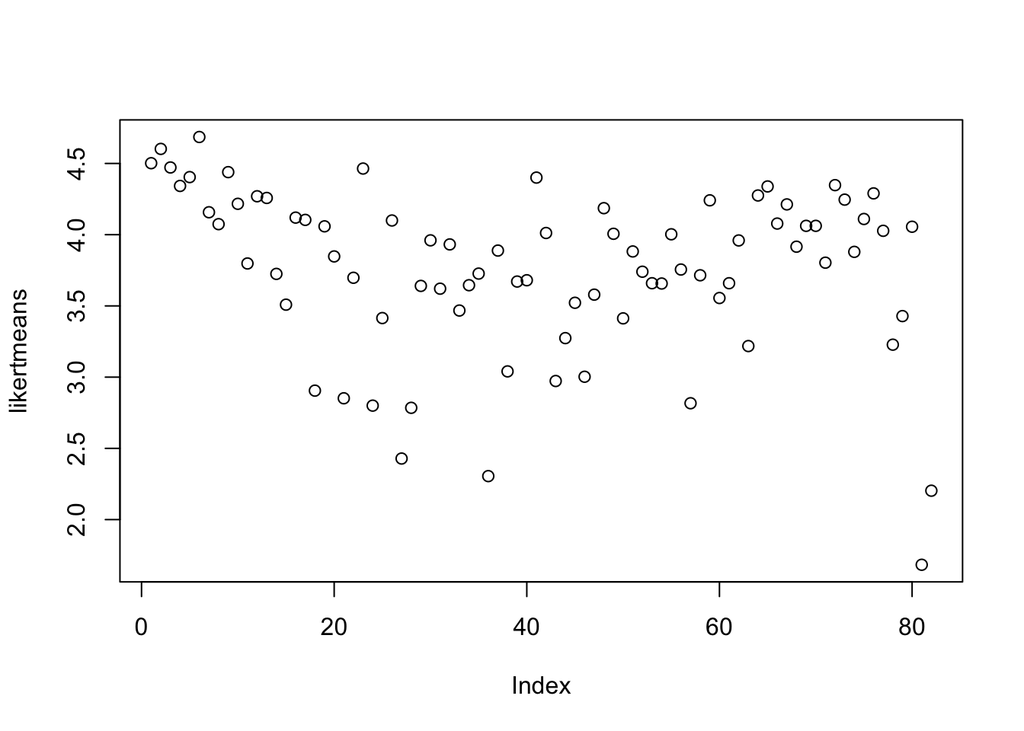

```r
#Mean response for all questions
likertmeans<-colMeans(data_likert)
#likertmeans<-sort(likertmeans) Option to sort in ascending/descending order
plot(likertmeans)
```

/newline The below code contains two ways to code uncertainty.  
The first way is very coarse, and uses question mean as a way to estimate uncertainty. However, one would expect both questions with a large proportion of 3s and questions with similar proportions of 2/4s or 1/5s to have a mean near 3.

```r
#Uncertainty column: questions with mean responses between 2.5 and 3.5
uncertain<-rep(0, length(likertmeans))
for(i in 1:length(likertmeans)){
  if (likertmeans[i]>3.5) {uncertain[i]<-"other"}
  else if (likertmeans[i]<2.5) {uncertain[i]<-"other"}
  else {uncertain[i]<-"uncertain"}
}
likertmeans<-as.data.frame(likertmeans)
#likertmeans$uncertain<-uncertain
likertmeans$Variable<-row.names(likertmeans)
head(uncertain)
```

```
## [1] "other" "other" "other" "other" "other" "other"
```

```r
#Uncertainty column: proportion of 3s
fun3<-function(x) {
  sum(x==3)/sum(is.na(x)==FALSE)
}
freq<-as.data.frame(apply(data_likert, 2, fun3))
colnames(freq)<-c("proportion")
proportion<-freq$proportion
freq<-gt(as.data.frame(freq), rownames_to_stub = TRUE)
freq<-
  freq |>
  tab_header( title="Questions by Uncertainty") |>
  tab_stubhead(label="Question") |>
  tab_source_note(source_note="Uncertainty is calculated by the proportion of 'Neither Agree nor Disagree' responses. Highlighted questions have uncertain answers at least 20% of the time.") |>
  cols_label(proportion="Proportion")|>
  tab_style(style=list(cell_fill(color="lightblue")), locations=cells_body(columns=everything(), rows=proportion>0.2))|>
  fmt_number(columns=everything(), rows=everything(), decimals=8)
#gtsave(freq, "UncertainQuest2.png", vwidth=500, vheight=2000)
```

```r
likertmeans$proportion<-proportion
likertmeans$uncertain<-ifelse(likertmeans$proportion>0.3, "uncertain", "certain")
head(likertmeans)
```

```
##                   likertmeans          Variable proportion uncertain
## Q2_leadership        4.501742     Q2_leadership 0.08013937   certain
## Q2_law               4.602091            Q2_law 0.05714286   certain
## Q2_implementation    4.471777 Q2_implementation 0.08153310   certain
## Q2_design            4.342160         Q2_design 0.11707317   certain
## Q2_supervision       4.404181    Q2_supervision 0.07456446   certain
## Q2_ccp               4.685714            Q2_ccp 0.04181185   certain
```

```r
cluster_codebook<-full_join(codebook, likertmeans, join_by(Variable==Variable))
cluster_codebook$uncertain<-as.factor(cluster_codebook$uncertain)
head(cluster_codebook)
```

```
## # A tibble: 6 × 5
##   Variable          Question                    likertmeans proportion uncertain
##   <chr>             <chr>                             <dbl>      <dbl> <fct>
## 1 reward            非常感谢您支持我们开展中国…       NA       NA      <NA>
## 2 Q2_leadership     设想一名来自国外的市长希望…        4.50     0.0801 certain
## 3 Q2_law            设想一名来自国外的市长希望…        4.60     0.0571 certain
## 4 Q2_implementation 设想一名来自国外的市长希望…        4.47     0.0815 certain
## 5 Q2_design         设想一名来自国外的市长希望…        4.34     0.117  certain
## 6 Q2_supervision    设想一名来自国外的市长希望…        4.40     0.0746 certain
```

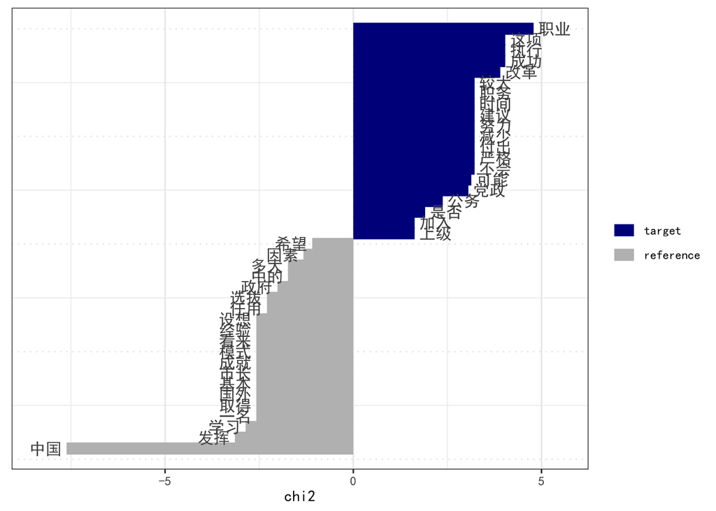

```r
#Comparison Plot
stopword_ch<-stopwords("zh", source="misc")
tokens_uncertain<-cluster_codebook %>% drop_na(uncertain)
tokens_uncertain<-corpus(tokens_uncertain$Question, docvars = data.frame(variable=tokens_uncertain$Variable, uncertain=tokens_uncertain$uncertain))
tokens_uncertain<- tokens_uncertain %>% tokens(remove_punct = TRUE, remove_numbers = TRUE) %>% tokens_remove(pattern = stopword_ch, min_nchar=2)
dfm_uncertain <- dfm(tokens_uncertain)
dfm1<-dfm_remove(dfm1, pattern=c("党员"))
dfm_uncertain<-dfm_trim(dfm_uncertain, min_termfreq = 0.3, termfreq_type = "quantile")

key_uncertain <- textstat_keyness(dfm_uncertain, target=docvars(dfm_uncertain, "uncertain") =="uncertain")
textplot_keyness(key_uncertain, font="SimHei")
```

```r
#create two subsets for uncertain and other
cluster1<-cluster_codebook %>% filter(uncertain=="uncertain")
cluster2<-cluster_codebook %>% filter(uncertain=="certain")
#Natural Text Analysis
cluster_uncertain<-corpus(cluster1$Question, docvars = data.frame(variable=cluster1$Variable, uncertain=cluster1$uncertain))
cluster_other<-corpus(cluster2$Question, docvars = data.frame(variable=cluster2$Variable, uncertain=cluster2$uncertain))
#define stopwords
stopword_ch<-stopwords("zh_cn", source="marimo")
#tokenize
tokens_uncertain <- cluster_uncertain %>% tokens(remove_punct = TRUE, remove_numbers = TRUE) %>% tokens_remove(pattern = stopword_ch, min_nchar=2)
tokens_other <- cluster_other %>% tokens(remove_punct = TRUE, remove_numbers = TRUE) %>% tokens_remove(pattern = stopword_ch, min_nchar=2)
#create dfm
dfm_uncertain<-dfm(tokens_uncertain)
dfm_other<-dfm(tokens_other)
#dfm_uncertain<-dfm_remove(dfm_uncertain, pattern=c("以下", "是否", "同意", "因素", "中国", "重要性","程度")) <--to remove words that appear frequently in both
topfeatures(dfm_uncertain, n=30)
```

```
##   是否   同意   以下   改革   职业   论述   党政   如下   公务   这项   成功
##     13     10      9      7      7      6      6      6      6      5      5
##   上级   执行   回想   加入   机构   因素   选择 重要性   程度   干部   政策
##      5      5      5      5      5      5      5      5      5      4      4
##   说法   愿意   开展   领导   工作   概率   判断   观察
##      4      3      3      3      3      2      2      2
```

```r
#dfm_other<-dfm_remove(dfm_other, pattern=c("以下", "是否", "同意", "因素", "中国", "重要性","程度"))
topfeatures(dfm_other, n=30)
```

```
##   以下   因素   是否   中国   同意 重要性   程度   干部   如下   发挥   学习
##     38     30     29     26     26     20     20     19     18     15     14
##   设想   一名   来自   国外   市长   希望   模式   基本   经验   看来   取得
##     13     13     13     13     13     13     13     13     13     13     13
##   成就   工作   观察   论述   影响   选拔   任用   政府
##     13     13     12     12     12     12     12     11
```

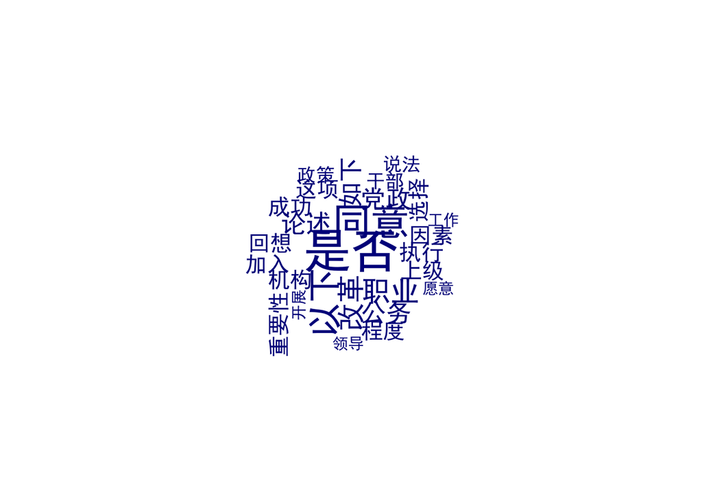

```r
#wordclouds
textplot_wordcloud(dfm_uncertain, font="SimHei")
```

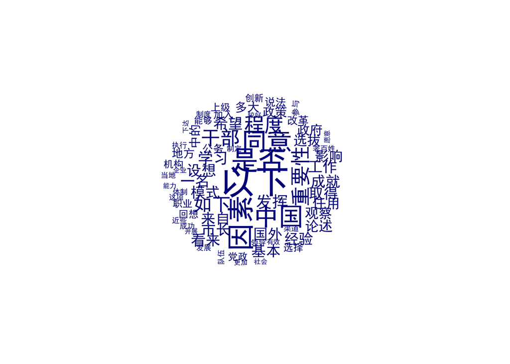

```r
textplot_wordcloud(dfm_other, font="SimHei")
```

/newline This code allows for a manual look at the most frequently used *phrases* in the questions.

```r
#ngrams for uncertain
ng_uncertain<-tokens_ngrams(tokens_uncertain, n=2:4)
dfm_uncertain1<-dfm(ng_uncertain)
topfeatures(dfm_uncertain1, n=20)
```

```
##      是否_同意      同意_如下 是否_同意_如下      这项_改革      改革_成功
##             10              6              6              5              5
## 这项_改革_成功      回想_加入      加入_党政      党政_机构      机构_以下
##              5              5              5              5              5
##      以下_因素      因素_职业      职业_选择    选择_重要性    重要性_程度
##              5              5              5              5              5
## 回想_加入_党政 加入_党政_机构 党政_机构_以下 机构_以下_因素 以下_因素_职业
##              5              5              5              5              5
```

```r
#ngrams for other
ng_other<-tokens_ngrams(tokens_other, n=2:4)
dfm_other1<-dfm(ng_other)
topfeatures(dfm_other1, n=20)
```

```
##      以下_因素      是否_同意    重要性_程度      同意_如下 是否_同意_如下
##             30             26             20             18             18
##      设想_一名      一名_来自      来自_国外      国外_市长      市长_希望
##             13             13             13             13             13
##      希望_学习      学习_中国      中国_模式      模式_基本      基本_经验
##             13             13             13             13             13
##      经验_看来      看来_以下      因素_中国      中国_取得      取得_成就
##             13             13             13             13             13
```

/newline /newline Topic analysis code:  
Allows for a factor analysis to identify “underlying topics” in the question categories.

```r
dfm_uncertain1<-dfm_trim(dfm_uncertain, min_termfreq = 0.5, termfreq_type = "quantile", max_docfreq = 0.5, docfreq_type = "prop")
dfm_other1<-dfm_trim(dfm_other, min_termfreq = 0.5, termfreq_type = "quantile", max_docfreq = 0.5, docfreq_type = "prop")
#dfm2<-dfm_trim(dfm1, min_termfreq = 0.8, termfreq_type = "quantile",        #max_docfreq = 0.1, docfreq_type = "prop")
topic2<-textmodel_lda(dfm_uncertain1, k = 5) #arbitrary, tune k
topic3<-textmodel_lda(dfm_other1, k=5)
#topic4<-textmodel_lda(dfm2, k=10)
```

Here are the topics of the uncertain questions:

```r
#uncertain
seededlda::terms(topic2, 10)
```

```
##       topic1   topic2   topic3 topic4 topic5
##  [1,] "以下"   "改革"   "执行" "干部" "论述"
##  [2,] "党政"   "这项"   "上级" "如下" "公务"
##  [3,] "职业"   "成功"   "严格" "说法" "政策"
##  [4,] "回想"   "愿意"   "按照" "领导" "上级"
##  [5,] "加入"   "开展"   "情况" "以下" "建议"
##  [6,] "机构"   "判断"   "付出" "发展" "如下"
##  [7,] "因素"   "制定"   "努力" "工作" "近些"
##  [8,] "选择"   "概率"   "不会" "我有" "制度"
##  [9,] "重要性" "观察"   "职业" "能力" "队伍"
## [10,] "程度"   "十年前" "观察" "概率" "减少"
```

And the certain questions:

```r
#other
seededlda::terms(topic3, 10)
```

```
##       topic1   topic2 topic3 topic4 topic5
##  [1,] "程度"   "是否" "干部" "同意" "中国"
##  [2,] "重要性" "如下" "观察" "是否" "发挥"
##  [3,] "因素"   "同意" "影响" "政策" "设想"
##  [4,] "回想"   "说法" "选拔" "政府" "一名"
##  [5,] "加入"   "公务" "任用" "论述" "来自"
##  [6,] "党政"   "改革" "因素" "执行" "国外"
##  [7,] "机构"   "地方" "中的" "上级" "市长"
##  [8,] "职业"   "工作" "多大" "参与" "希望"
##  [9,] "选择"   "当地" "工作" "制定" "模式"
## [10,] "能够"   "这项" "能力" "有效" "基本"
```

```r
#terms(topic4, 10)
```

Much like the previous charts, these could all be improved by defining dictionaries of words used in the questions and dictionarys of stop words to be ignored.

/newline

/newline

Respondent uncertainty:  
Here we take a quick look at the mean response for each respondent. The average response seems to hover around 3.7.

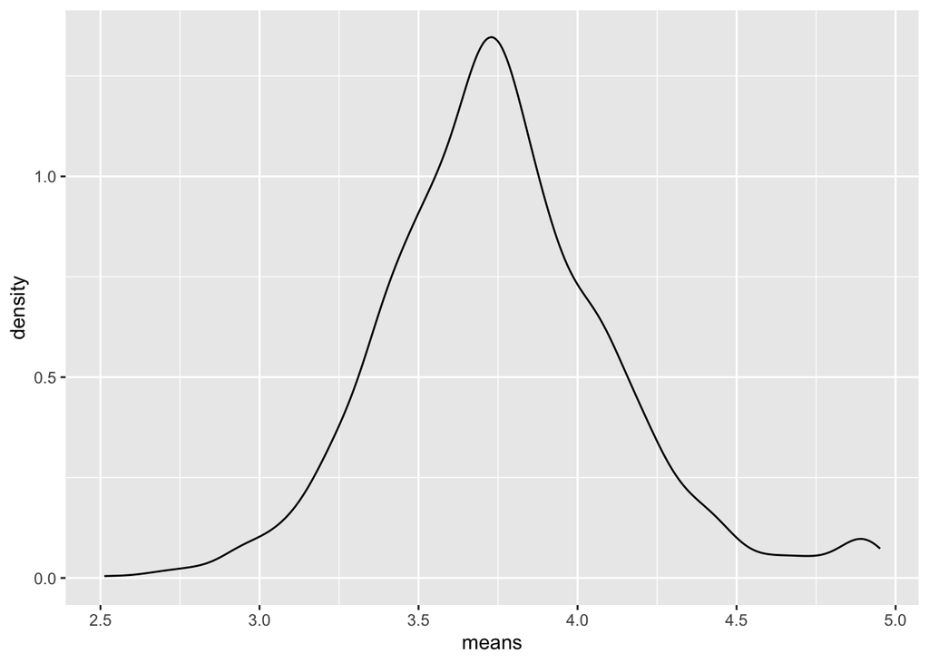

```r
likertmeans2<-rowMeans(data_likert)
#plot
lm2<-as.data.frame(likertmeans2)
colnames(lm2)<-c("means")
ggplot(data=lm2)+geom_density(aes(x=means))
```

```r
#uncertainty column (case basis)
data_likert$uncertain<-rep(0, 1435)
```

This is code to identify respondent uncertainty by mean response, which is unused.

```
data_likert$uncertain<- ifelse(likertmeans2>3.5 | likertmeans2<2.5, "other", "uncertain")
head(data_likert$uncertain)
data_numeric$uncertain<-as.factor(data_likert$uncertain)
```

This code defines uncertainty as the proportion of 3s.  
The average proportion of 3s is near 20 percent.

```r
fun3<-function(x) {sum(x==3)/sum(is.na(x)==FALSE)}
unpercent<-apply(data_likert, 1, fun3)
head(unpercent)
```

```
## [1] 0.09638554 0.01204819 0.27710843 0.00000000 0.59036145 0.02409639
```

```r
mean(unpercent)
```

```
## [1] 0.2105789
```

/newline

Here, a linear regression is used to identify which demographic variables vary by certainty of respondent. The output identifies which variables vary significantly with how certain the respondent is.

```r
demo<-cbind(data1[,c(146:154, 156, 157)]) #demographic variables only
demo$unpercent<-unpercent
mod<-lm(unpercent~gender+birthyear+ethics+education+political+govlevel+poslevel+leadership+workyear+nativecadre+localcadre, demo)
summary(mod)
```

```
##
## Call:
## lm(formula = unpercent ~ gender + birthyear + ethics + education +
##     political + govlevel + poslevel + leadership + workyear +
##     nativecadre + localcadre, data = demo)
##
## Residuals:
##      Min       1Q   Median       3Q      Max
## -0.25627 -0.06967 -0.00335  0.05726  0.62673
##
## Coefficients: (1 not defined because of singularities)
##                 Estimate Std. Error t value Pr(>|t|)
## (Intercept)   -0.2369051  0.1557572  -1.521  0.12850
## gender         0.0078844  0.0059673   1.321  0.18663
## birthyear1952  0.5377247  0.1869659   2.876  0.00409 **
## birthyear1953  0.3411455  0.1745874   1.954  0.05091 .
## birthyear1954  0.4319048  0.1734312   2.490  0.01288 *
## birthyear1960  0.1293133  0.1639342   0.789  0.43036
## birthyear1962  0.3241883  0.1386804   2.338  0.01955 *
## birthyear1963  0.2106231  0.1280502   1.645  0.10024
## birthyear1964  0.1634547  0.1378486   1.186  0.23593
## birthyear1965  0.2335582  0.1240539   1.883  0.05996 .
## birthyear1966  0.2168721  0.1269615   1.708  0.08784 .
## birthyear1967  0.1562659  0.1451047   1.077  0.28171
## birthyear1968  0.2488616  0.1371810   1.814  0.06988 .
## birthyear1970  0.1128836  0.1191774   0.947  0.34371
## birthyear1971  0.1009665  0.1185556   0.852  0.39457
## birthyear1972  0.1309352  0.1175889   1.114  0.26569
## birthyear1973  0.1841435  0.1226593   1.501  0.13352
## birthyear1974  0.1576121  0.1213181   1.299  0.19411
## birthyear1975  0.1477986  0.1214170   1.217  0.22371
## birthyear1976  0.0950341  0.1195924   0.795  0.42696
## birthyear1977  0.1705138  0.1133669   1.504  0.13280
## birthyear1978  0.2312630  0.1133614   2.040  0.04154 *
## birthyear1979  0.1713175  0.1114439   1.537  0.12447
## birthyear1980  0.1555880  0.1103134   1.410  0.15865
## birthyear1981  0.1630959  0.1103510   1.478  0.13965
## birthyear1982  0.2255939  0.1100290   2.050  0.04053 *
## birthyear1983  0.1574605  0.1098339   1.434  0.15191
## birthyear1984  0.1766427  0.1100040   1.606  0.10856
```

[output cut: 63 more lines]

```
## workyear2016   0.1955548  0.1078931   1.812  0.07014 .
## workyear2017   0.2042661  0.1078404   1.894  0.05842 .
## workyear2018   0.1879398  0.1078211   1.743  0.08155 .
## workyear2019   0.1791390  0.1080137   1.658  0.09745 .
## workyear2020   0.2042220  0.1079981   1.891  0.05884 .
## workyear2021   0.1611404  0.1086479   1.483  0.13827
## workyear2022   0.1588359  0.1095660   1.450  0.14738
## nativecadre    0.0057925  0.0029650   1.954  0.05096 .
## localcadre     0.0030782  0.0033646   0.915  0.36042
## ---
## Signif. codes:  0 '***' 0.001 '**' 0.01 '*' 0.05 '.' 0.1 ' ' 1
##
## Residual standard error: 0.1061 on 1336 degrees of freedom
## Multiple R-squared:  0.08661,    Adjusted R-squared:  0.01961
## F-statistic: 1.293 on 98 and 1336 DF,  p-value: 0.0328
```